# Community Biplot

Ben Weinstein

July 2, 2015

```r
library(vegan)
```

```r
library(ggbiplot)
library(reshape2)
set.seed(1)
```

Create some data which would hopefully match the input data

## Site by species matrix

- 15 species
- 20 sites

## Trait matrix

- Six traits

```r
siteXspp<-matrix(nrow=15,ncol=20,data=rbinom(15*20,1,.5))
traits<-matrix(nrow=15,ncol=6,data = rpois(60,10))

#give some names to make it easier to follow, won't really on sorting order.
rownames(siteXspp)<-paste("Species",1:nrow(siteXspp))
colnames(siteXspp)<-paste("Site",1:ncol(siteXspp))
colnames(traits)<-paste("Trait",1:ncol(traits))
rownames(traits)<-paste("Species",1:nrow(traits))
```

Start with mean traits

For each site (column) get the mean trait distance

```r
#container for site trait averages
out<-matrix(nrow=ncol(siteXspp),ncol=ncol(traits))

for (x in 1:ncol(siteXspp)){
  #subset site
  site<-siteXspp[,x]

  #get the trait matrix for species that are present
  site.trait<-traits[rownames(traits) %in% names(site[site==1]),]
  #mean position
  out[x,]<-apply(site.trait,2,mean)
}

#name container based on sites
rownames(out)<-colnames(siteXspp)
colnames(out)<-colnames(traits)
```

Initial biplot

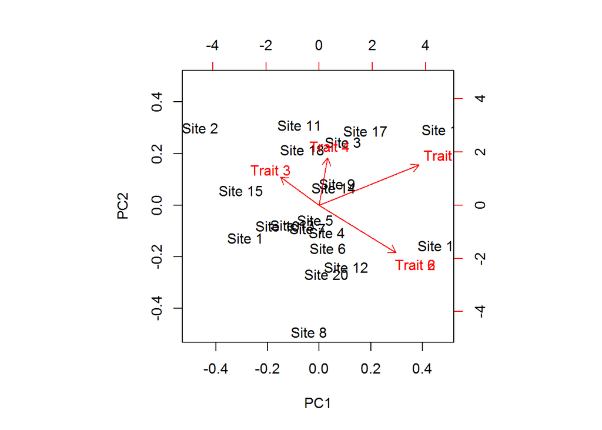

```r
#base package
biplot(prcomp(out))
```

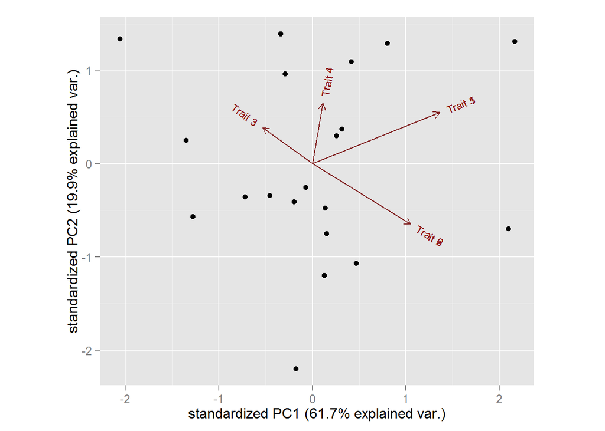

```r
#ggbiplot
ggbiplot((prcomp(out)))
```

Okay so that what it would look like in one time slice. Let’s add a new matrix, which is the future siteXspp.

```r
siteXsppF<-matrix(nrow=15,ncol=20,data=rbinom(15*20,1,.5))
rownames(siteXsppF)<-paste("Species",1:nrow(siteXspp))
colnames(siteXsppF)<-paste("FutureSite",1:ncol(siteXspp))
```

Repeat trait calculation

```r
#container for site trait averages
outF<-matrix(nrow=ncol(siteXsppF),ncol=ncol(traits))

for (x in 1:ncol(siteXsppF)){
  #subset site
  site<-siteXsppF[,x]

  #get the trait matrix for species that are present
  site.trait<-traits[rownames(traits) %in% names(site[site==1]),]
  #mean position
  outF[x,]<-apply(site.trait,2,mean)
}

#name container based on sites
rownames(outF)<-colnames(siteXsppF)
colnames(outF)<-colnames(traits)
```

## Approach #1: Bind the dataframes together

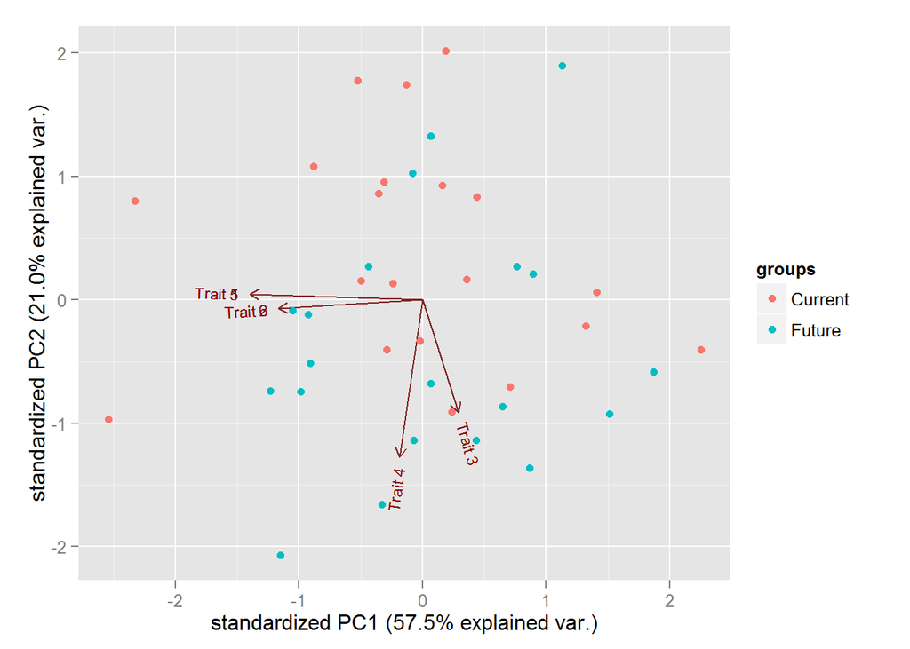

```r
combin<-rbind(out,outF)
pca<-princomp(combin)
#lets make a grouping variable, so the plot knows which is current and which is future
groups<-c(rep("Current",nrow(out)),rep("Future",nrow(outF)))
ggbiplot(pca,groups=groups)
```

So maybe we want to connect each assemblage by a faint line? Lots of different visualizations we could try

If the two data.frames out (current) and outF (future) are just bound together in a dataframe (combin), and they are ordered in the same manner, then the first row of combin is the current state of the assemblage and the 1+nrow(out) row of combin is the future state of that assemblage. If they are not ordered correctly, you could match off a row name or lookup table by cell number?

### Draw Lines

So as an example, line segements can be drawn in ggplot like this.

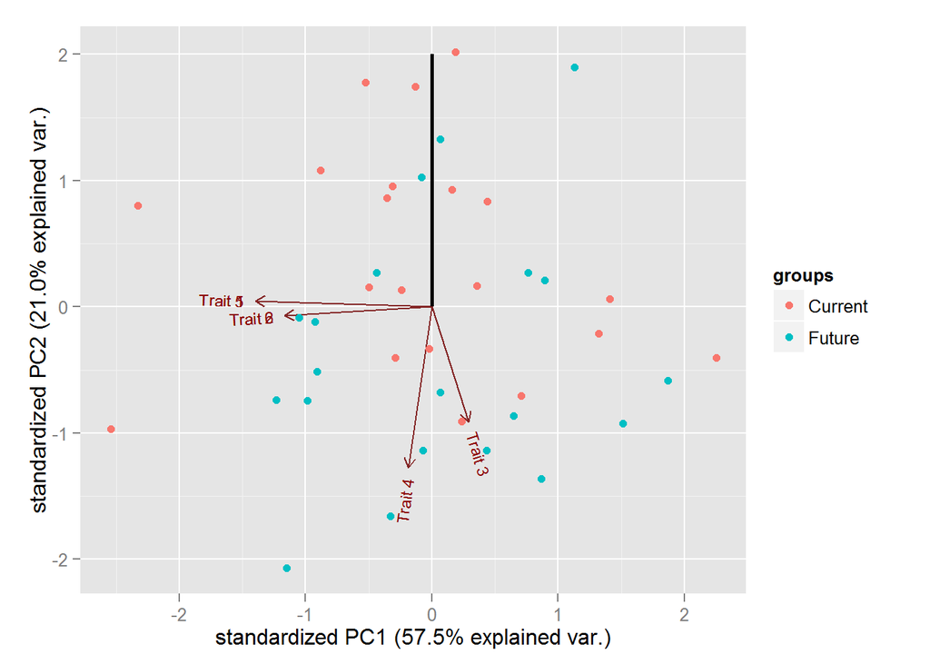

```r
ggbiplot(pca,groups=groups) + geom_segment(x=0,y=0,xend=0,yend=2,size=1)
```

So the goal is to get the pca coordinates of each pair, and pass them into geom_segement.

Step 1 is to get the correct pair for each line segement. The scores hold the pca loadings that act as coordinates in the figure. We just use the first two PC axis

As an example show the first site

```r
#begin coordinates
coords<-pca$scores[c(1,nrow(out)+1),1:2]

#rename to make more logical
colnames(coords)<-c("x","y")
rownames(coords)<-c("Begin","End")

#rearrange the data
mcoords<-melt(coords)
df<-dcast(mcoords,...~Var2+Var1)
df
```

```
##   .  x_Begin     x_End    y_Begin    y_End
## 1 . 2.276517 0.1166517 -0.2195463 1.387359
```

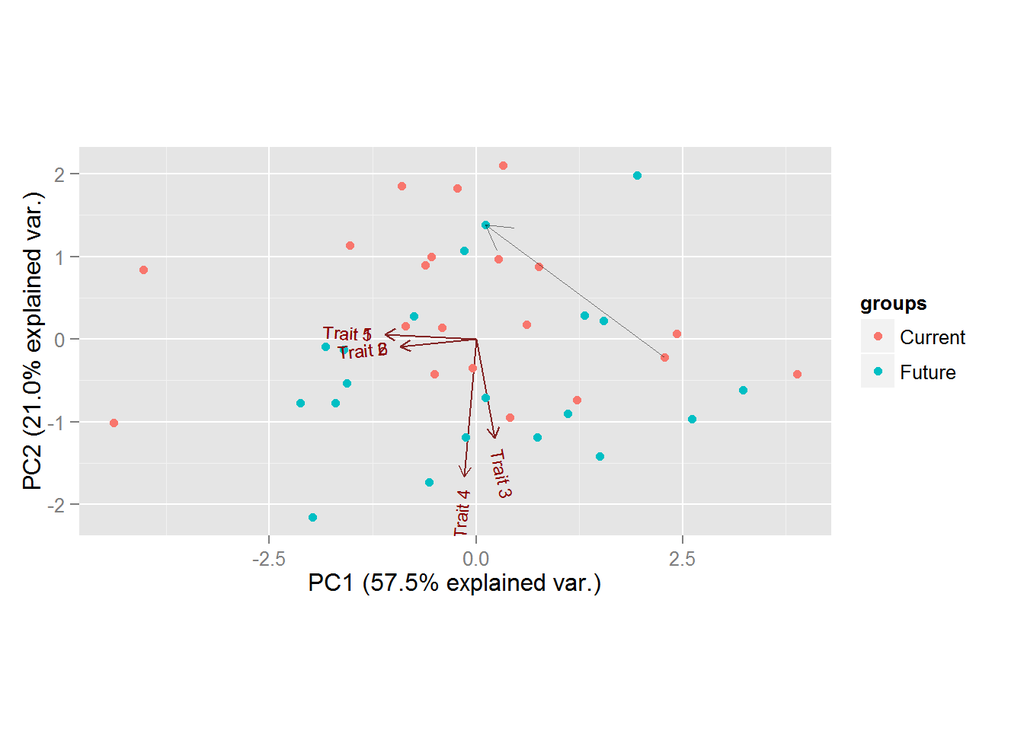

```r
ggbiplot(pca,groups=groups,scale = 0) + geom_segment(data=df,aes(x=x_Begin,y=y_Begin,xend=x_End,yend=y_End),size=.1,alpha=.5, arrow = arrow(length = unit(0.5,"cm")))
```

Repeat this all current assemblages.

```r
#begin coordinates
df<-list()

for (x in 1:nrow(out)){
coords<-pca$scores[c(x,nrow(out)+x),1:2]

#rename to make more logical
colnames(coords)<-c("x","y")
rownames(coords)<-c("Begin","End")

#rearrange the data
mcoords<-melt(coords)
df[[x]]<-dcast(mcoords,...~Var2+Var1)[,-1]
}

df<-rbind.fill(df)
```

plot

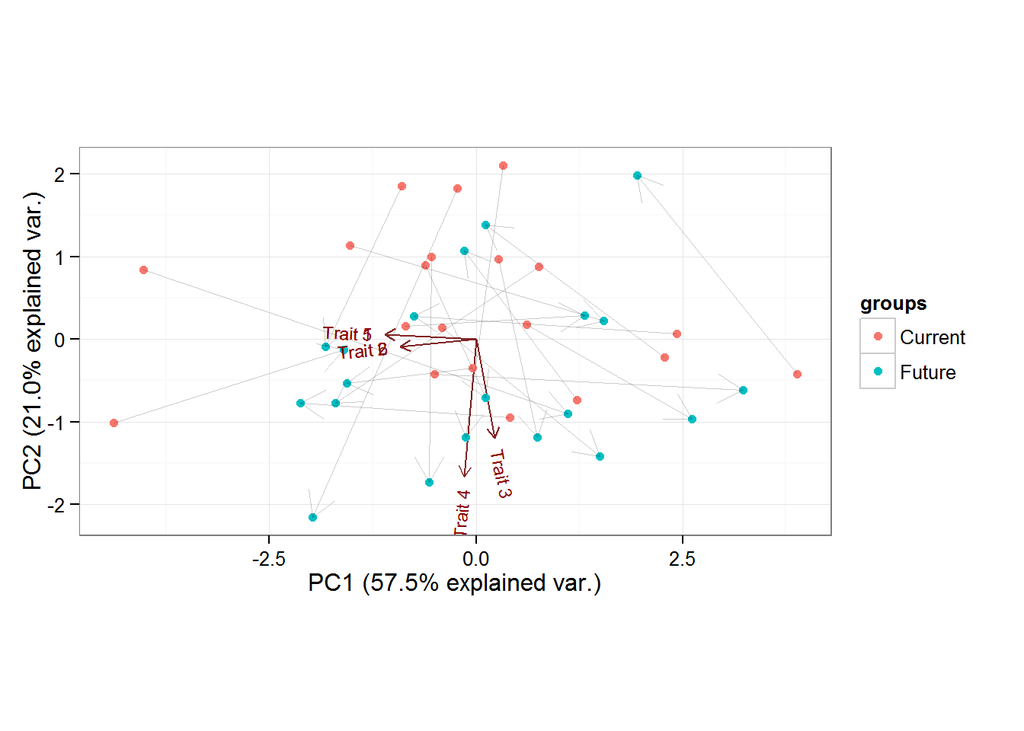

```r
ggbiplot(pca,groups=groups,scale = 0) + geom_segment(data=df,aes(x=x_Begin,y=y_Begin,xend=x_End,yend=y_End),size=.1,alpha=.2, arrow = arrow(length = unit(0.5,"cm"))) + theme_bw()
```

Okay, so this data was constructed randomly, but it looks like its a reasonable approach. Hopefully there is more pattern than that. We could play without a bit more (drop the points and just show the arrows?). Hopefully that illustrates where i’m going with this.

Crucially, this setup relies on scale = F for the biplot. This is where there is no added transformation, known as a ‘form biplot’. Depending on the real data we can work on it if there are additional complications.

For the help screen

```
covariance biplot (scale = 1), form biplot (scale = 0). When scale = 1, the inner product between the variables approximates the covariance and the distance between the points approximates the Mahalanobis distance.
```